# Estero Santa Cruz Water Temp

Abram B. Fleishman

November 1, 2015

I found some water temperature data from Estero Santa Cruz, Sonora, MX from 2006-2014. The data were found here: http://cosaesobr.dyndns.org:85/tempcosaes/termografos2.aspx?enviar=Entrar+al+Sistema Pick: “JSLA Bahia de Kino”, “Estero Santa Cruz”, “1/1/2000” to “1/1/2015”

# Load Data

First we we Load the data

```r
a<-read.csv("~/Downloads/Workbook5.csv")
a$date<-dmy(a$Fecha)
head(a)
```

```
##   TempMinima TempMaxima TempPromedio  Fecha       date
## 1     12.497     16.141     14.41158 1/1/07 0007-01-01
## 2     10.651     14.996     12.59852 1/1/08 0008-01-01
## 3     14.230     17.189     15.62956 1/1/09 0009-01-01
## 4     12.207     15.760     13.85827 1/1/11 0011-01-01
## 5     12.980     18.140     15.17844 1/1/12 0012-01-01
## 6     14.230     18.426     16.50921 1/1/14 0014-01-01
```

You can see that there are daily minimum, maximum, and mean temperatures along with a date column. However, when I tried to plot the data Ifound that the date is all screwed up. Some of the years were four digits and some were two digits eg 2006 vs 06, so we need to fix it before we can make a pretty plot.

# Clean it up a bit

First I will seperate the date string using the function seperate from the tidyr package.

```r
a<-separate(a,Fecha,into=c("day","month","year"),sep="/")
head(a)
```

```
##   TempMinima TempMaxima TempPromedio day month year       date
## 1     12.497     16.141     14.41158   1     1   07 0007-01-01
## 2     10.651     14.996     12.59852   1     1   08 0008-01-01
## 3     14.230     17.189     15.62956   1     1   09 0009-01-01
## 4     12.207     15.760     13.85827   1     1   11 0011-01-01
## 5     12.980     18.140     15.17844   1     1   12 0012-01-01
## 6     14.230     18.426     16.50921   1     1   14 0014-01-01
```

Then I need to change all the two digit years into four digit years. and then paste the day month year data back into a date

```r
a$year[nchar(a$year)==2]<-paste(20,a$year[nchar(a$year)==2],sep="")
a$Date<-ymd(paste(a$year,a$month, a$day))

head(a)
```

```
##   TempMinima TempMaxima TempPromedio day month year       date       Date
## 1     12.497     16.141     14.41158   1     1 2007 0007-01-01 2007-01-01
## 2     10.651     14.996     12.59852   1     1 2008 0008-01-01 2008-01-01
## 3     14.230     17.189     15.62956   1     1 2009 0009-01-01 2009-01-01
## 4     12.207     15.760     13.85827   1     1 2011 0011-01-01 2011-01-01
## 5     12.980     18.140     15.17844   1     1 2012 0012-01-01 2012-01-01
## 6     14.230     18.426     16.50921   1     1 2014 0014-01-01 2014-01-01
```

# Plot the data

Now we should be able to plot the data

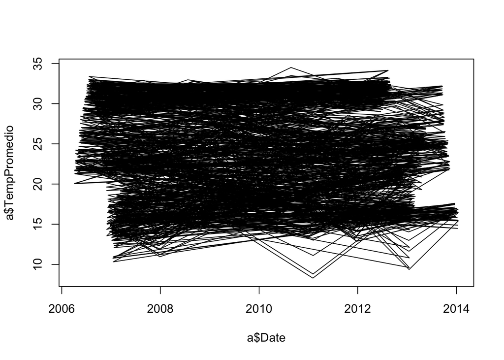

```r
plot(a$Date,a$TempPromedio,type="l")
```

Oops! What is that? The output is all messed up because the data are not sorted correctly (in time oder).

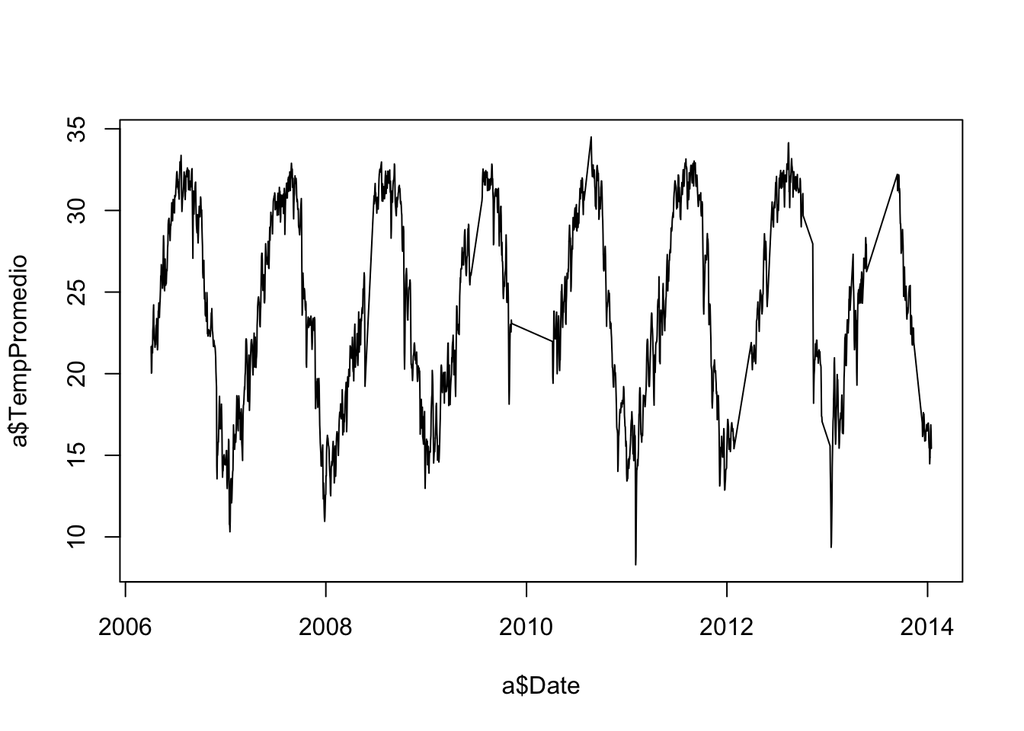

```r
a<-arrange(a,Date)
plot(a$Date,a$TempPromedio,type="l")
```

That is a lot better! Now lets take a 15 day rolling mean and plot that as a line along with the points.

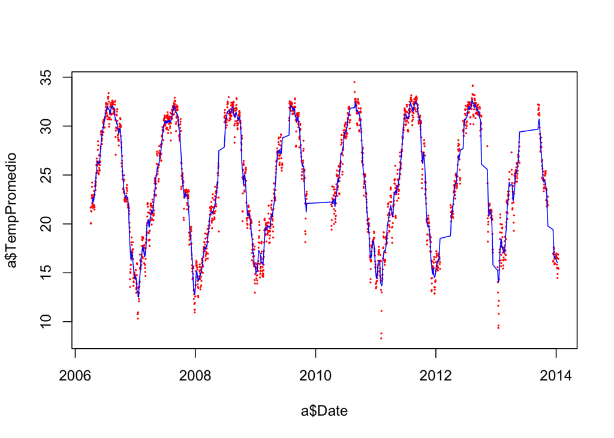

```r
a$roll<-rollmean(a$TempPromedio,15,na.pad = T)
plot(a$Date,a$TempPromedio,cex=.3,pch=16,type="p",col="red")
lines(a$Date,a$roll,col="blue")
```

You can see that there are some gaps in the data but this is looking pritty good.

# Mean by julian day

Now I want to make a plot of mean temperature by day of year. First I need to calculate julian date. Then summarize the mean temperature by the julian date.

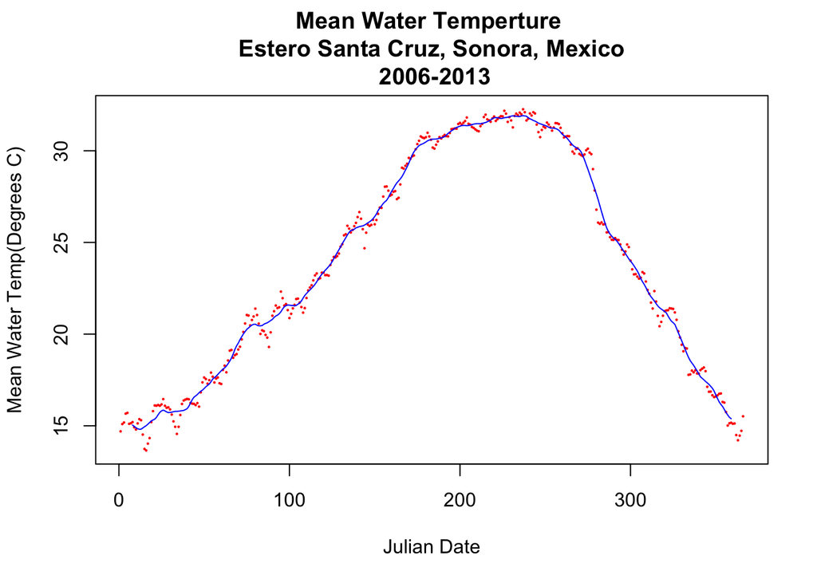

```r
a$jdate<-yday(a$Date)
b<-summarise(group_by(a, jdate), mean=mean(TempPromedio), sd=sd(TempPromedio))
b$roll<-rollmean(b$mean,15,na.pad = T)
plot(b$jdate,b$mean,cex=.3,pch=16,type="p",col="red",xlab="Julian Date",ylab="Mean Water Temp(Degrees C)",main="Mean Water Temperture \n Estero Santa Cruz, Sonora, Mexico \n 2006-2013")
lines(b$jdate,b$roll,col="blue",type="l")
```